# Tugas-Pertemuan-2

## Tugas

1. Setiap kelompok memilih satu data time series dengan panjang ≥ 500 periode.
2. Data dibagi rata ke setiap anggota; minimal 100 observasi per orang.
3. Terapkan metode pemulusan yang sudah dipelajari (SMA, DMA, SES, DES, atau Holt-Winters) pada bagian data masing-masing
4. Bandingkan kinerja metode dan tentukan metode terbaik untuk data tersebut menggunakan metrik akurasi (mis. SSE/MSE/RMSE/MAPE), lalu jelaskan alasannya secara singkat.

   Upload tugas per individu ke GitHub pada folder `Pertemuan-2` dengan format HTML bernama `Tugas-Pertemuan-2.html`.

```r
library(forecast)
library(graphics)
library(TTR)
library(TSA)
library(rio)
library(ggplot2)
```

```r
# Impor data
data <- import("Beijing_Air_Quality_Rapi.csv")
head(data)
```

```
##   Periode Count
## 1       1   263
## 2       2   270
## 3       3   259
## 4       4   281
## 5       5   267
## 6       6   244
```

## Pembagian Data

```r
# Mengambil subset baris ke-583 hingga 776
data1 <- data[583:776, ]
str(data1)
```

```
## 'data.frame':    194 obs. of  2 variables:
##  $ Periode: int  583 584 585 586 587 588 589 590 591 592 ...
##  $ Count  : int  242 237 262 264 264 263 263 258 264 258 ...
```

```r
dim(data1)
```

```
## [1] 194   2
```

```r
n <- nrow(data1)
n_train <- floor(0.8 * n)
n_test <- n - n_train

latih <- data1[1:n_train, ]
uji <- data1[(n_train+1):n, ]

latih.ts <- ts(latih$Count)
uji.ts  <- ts(uji$Count)
```

```r
# Mengubah data agar terbaca sebagai data deret waktu
data.ts <- ts(data1$Count)

# Ringkasan data
summary(data.ts)
```

```
##    Min. 1st Qu.  Median    Mean 3rd Qu.    Max.
##    87.0   243.0   258.5   246.2   262.0   264.0
```

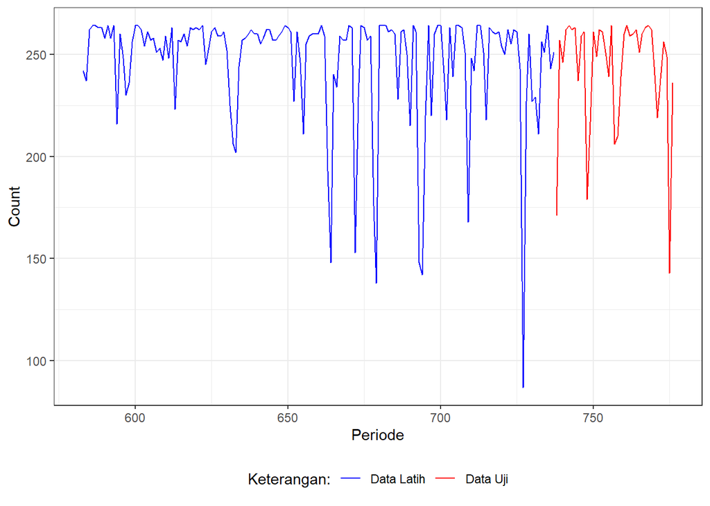

```r
# Plot data deret waktu keseluruhan
ggplot() +
  geom_line(data = latih, aes(x = Periode, y = Count, col = "Data Latih")) +
  geom_line(data = uji, aes(x = Periode, y = Count, col = "Data Uji")) +
  labs(x = "Periode", y = "Count", color = "Legend") +
  scale_colour_manual(name="Keterangan:", breaks = c("Data Latih", "Data Uji"),
                      values = c("blue", "red")) +
  theme_bw() + theme(legend.position = "bottom",
                     plot.caption = element_text(hjust=0.9, size=12))
```

# Single Moving Average

```r
# Pemulusan SMA dengan orde m = 4
data.sma <- SMA(latih.ts, n = 4)
data.sma
```

```
## Time Series:
## Start = 1
## End = 155
## Frequency = 1
##   [1]     NA     NA     NA 251.25 256.75 263.25 263.50 262.00 262.00 260.75
##  [11] 261.00 250.50 249.50 247.00 238.50 243.50 242.50 246.50 255.00 261.50
##  [21] 261.00 260.25 258.50 257.50 256.75 254.75 252.25 252.50 251.75 254.25
##  [31] 248.25 247.75 249.75 249.00 256.75 258.25 259.75 260.50 262.50 262.75
##  [41] 258.50 255.75 255.50 255.25 258.75 260.50 260.50 257.75 249.25 236.00
##  [51] 221.25 219.25 227.25 240.25 254.75 259.25 260.00 260.50 259.25 258.25
##  [61] 258.75 259.25 259.75 259.50 258.75 258.50 260.25 261.75 262.25 253.75
##  [71] 253.00 248.75 236.25 243.25 242.75 246.25 258.50 259.75 261.00 260.75
##  [81] 244.00 216.00 210.00 203.75 220.25 247.50 251.75 259.25 260.25 234.25
##  [91] 227.25 227.25 227.25 253.25 260.75 238.75 207.50 209.25 210.50 232.50
## [101] 263.25 262.75 261.75 252.75 252.75 252.75 250.25 247.00 247.75 247.50
## [111] 222.00 203.75 192.75 193.50 211.50 241.00 252.00 252.00 257.25 246.75
## [121] 246.50 240.25 246.00 257.50 257.50 260.50 236.50 232.50 227.25 230.50
## [131] 254.50 255.25 249.25 249.00 248.25 250.50 261.25 259.00 256.25 256.75
## [141] 255.25 257.25 260.00 255.25 213.25 204.50 204.25 200.25 235.75 231.75
## [151] 230.75 236.75 245.50 253.50 252.25
```

```r
data.ramal <- c(NA, data.sma)
data.ramal
```

```
##   [1]     NA     NA     NA     NA 251.25 256.75 263.25 263.50 262.00 262.00
##  [11] 260.75 261.00 250.50 249.50 247.00 238.50 243.50 242.50 246.50 255.00
##  [21] 261.50 261.00 260.25 258.50 257.50 256.75 254.75 252.25 252.50 251.75
##  [31] 254.25 248.25 247.75 249.75 249.00 256.75 258.25 259.75 260.50 262.50
##  [41] 262.75 258.50 255.75 255.50 255.25 258.75 260.50 260.50 257.75 249.25
##  [51] 236.00 221.25 219.25 227.25 240.25 254.75 259.25 260.00 260.50 259.25
##  [61] 258.25 258.75 259.25 259.75 259.50 258.75 258.50 260.25 261.75 262.25
##  [71] 253.75 253.00 248.75 236.25 243.25 242.75 246.25 258.50 259.75 261.00
##  [81] 260.75 244.00 216.00 210.00 203.75 220.25 247.50 251.75 259.25 260.25
##  [91] 234.25 227.25 227.25 227.25 253.25 260.75 238.75 207.50 209.25 210.50
## [101] 232.50 263.25 262.75 261.75 252.75 252.75 252.75 250.25 247.00 247.75
## [111] 247.50 222.00 203.75 192.75 193.50 211.50 241.00 252.00 252.00 257.25
## [121] 246.75 246.50 240.25 246.00 257.50 257.50 260.50 236.50 232.50 227.25
## [131] 230.50 254.50 255.25 249.25 249.00 248.25 250.50 261.25 259.00 256.25
## [141] 256.75 255.25 257.25 260.00 255.25 213.25 204.50 204.25 200.25 235.75
## [151] 231.75 230.75 236.75 245.50 253.50 252.25
```

```r
# Peramalan untuk n_test periode ke depan
data.gab <- cbind(
  aktual = c(data.ts),
  pemulusan = c(data.sma, rep(NA, n_test)),
  ramalan = c(data.ramal, rep(data.ramal[length(data.ramal)], n_test))
)
data.gab
```

```
##        aktual pemulusan ramalan
##   [1,]    242        NA      NA
##   [2,]    237        NA      NA
##   [3,]    262        NA      NA
##   [4,]    264    251.25      NA
##   [5,]    264    256.75  251.25
##   [6,]    263    263.25  256.75
##   [7,]    263    263.50  263.25
##   [8,]    258    262.00  263.50
##   [9,]    264    262.00  262.00
##  [10,]    258    260.75  262.00
##  [11,]    264    261.00  260.75
##  [12,]    216    250.50  261.00
##  [13,]    260    249.50  250.50
##  [14,]    248    247.00  249.50
```

[output cut: 181 more lines]

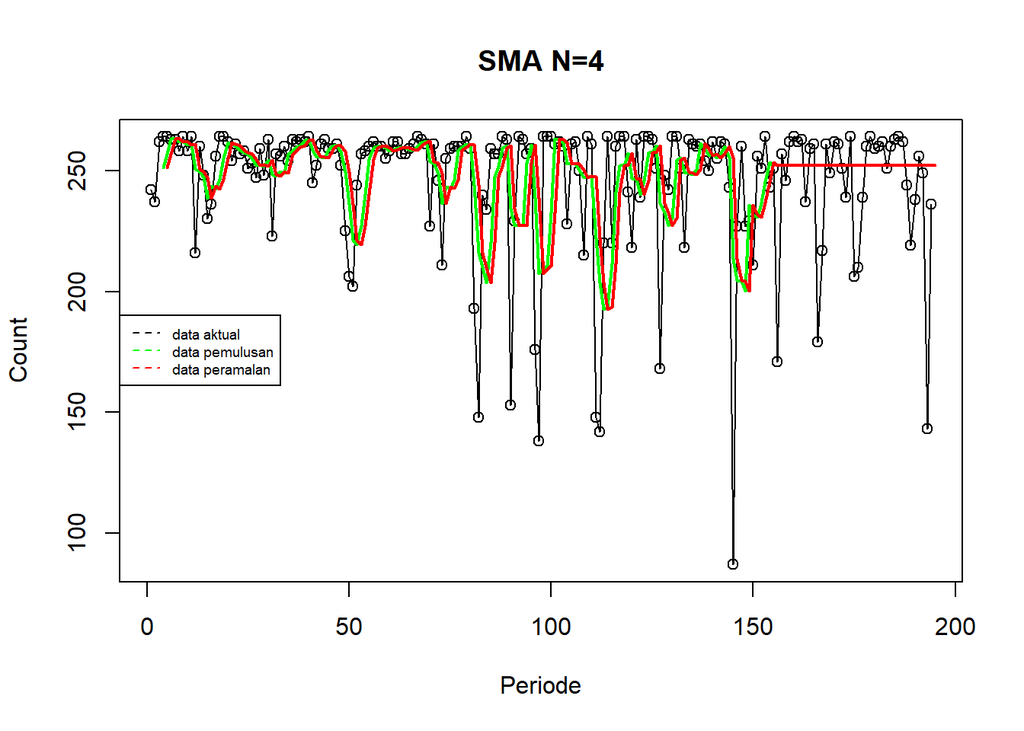

```r
# Plot SMA
ts.plot(data.ts, xlab="Periode", ylab="Count", main= "SMA N=4")
points(data.ts)
lines(data.gab[,2], col="green", lwd=2)
lines(data.gab[,3], col="red", lwd=2)
legend("left", c("data aktual", "data pemulusan", "data peramalan"), lty=8, col=c("black","green","red"), cex=0.6)
```

```r
# AKURASI DATA LATIH & UJI SMA
error_train.sma = latih.ts - data.ramal[1:length(latih.ts)]
SSE_train.sma = sum(error_train.sma[5:length(latih.ts)]^2)
MSE_train.sma = mean(error_train.sma[5:length(latih.ts)]^2)
MAPE_train.sma = mean(abs((error_train.sma[5:length(latih.ts)]/latih.ts[5:length(latih.ts)])*100))

error_test.sma = uji.ts - data.gab[(n_train+1):n, 3]
SSE_test.sma = sum(error_test.sma^2)
MSE_test.sma = mean(error_test.sma^2)
MAPE_test.sma = mean(abs((error_test.sma/uji.ts)*100))
```

# Double Moving Average

```r
dma <- SMA(data.sma, n = 4)
At <- 2*data.sma - dma
Bt <- 2/(4-1)*(data.sma - dma)
data.dma <- At + Bt
data.ramal2 <- c(NA, data.dma)

t = 1:n_test
f = c()

for (i in t) {
  f[i] = At[length(At)] + Bt[length(Bt)] * (i)
}

data.gab2 <- cbind(aktual = c(data.ts),
                   pemulusan1 = c(data.sma, rep(NA, n_test)),
                   pemulusan2 = c(dma, rep(NA, n_test)),
                   At = c(At, rep(NA, n_test)),
                   Bt = c(Bt, rep(NA, n_test)),
                   ramalan = c(data.ramal2, f))
data.gab2
```

```
##        aktual pemulusan1 pemulusan2       At          Bt  ramalan
##   [1,]    242         NA         NA       NA          NA       NA
##   [2,]    237         NA         NA       NA          NA       NA
##   [3,]    262         NA         NA       NA          NA       NA
##   [4,]    264     251.25         NA       NA          NA       NA
##   [5,]    264     256.75         NA       NA          NA       NA
##   [6,]    263     263.25         NA       NA          NA       NA
##   [7,]    263     263.50   258.6875 268.3125   3.2083333       NA
##   [8,]    258     262.00   261.3750 262.6250   0.4166667 271.5208
##   [9,]    264     262.00   262.6875 261.3125  -0.4583333 263.0417
##  [10,]    258     260.75   262.0625 259.4375  -0.8750000 260.8542
##  [11,]    264     261.00   261.4375 260.5625  -0.2916667 258.5625
##  [12,]    216     250.50   258.5625 242.4375  -5.3750000 260.2708
##  [13,]    260     249.50   255.4375 243.5625  -3.9583333 237.0625
##  [14,]    248     247.00   252.0000 242.0000  -3.3333333 239.6042
```

[output cut: 181 more lines]

```r
# AKURASI DATA LATIH & UJI DMA
error_train.dma = latih.ts - data.ramal2[1:length(latih.ts)]
SSE_train.dma = sum(error_train.dma[8:length(latih.ts)]^2)
MSE_train.dma = mean(error_train.dma[8:length(latih.ts)]^2)
MAPE_train.dma = mean(abs((error_train.dma[8:length(latih.ts)]/latih.ts[8:length(latih.ts)])*100))

error_test.dma = uji.ts - data.gab2[(n_train+1):n, 6]
SSE_test.dma = sum(error_test.dma^2)
MSE_test.dma = mean(error_test.dma^2)
MAPE_test.dma = mean(abs((error_test.dma/uji.ts)*100))
```

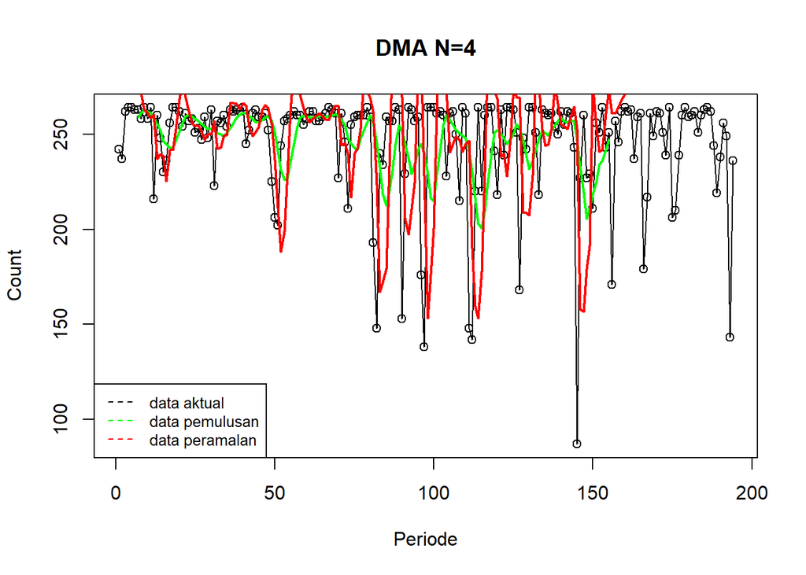

```r
# Plot DMA
ts.plot(data.ts, xlab="Periode", ylab="Count", main= "DMA N=4")
points(data.ts)
lines(data.gab2[,3], col="green", lwd=2)
lines(data.gab2[,6], col="red", lwd=2)
legend("bottomleft", c("data aktual", "data pemulusan", "data peramalan"), lty=8, col=c("black","green","red"), cex=0.8)
```